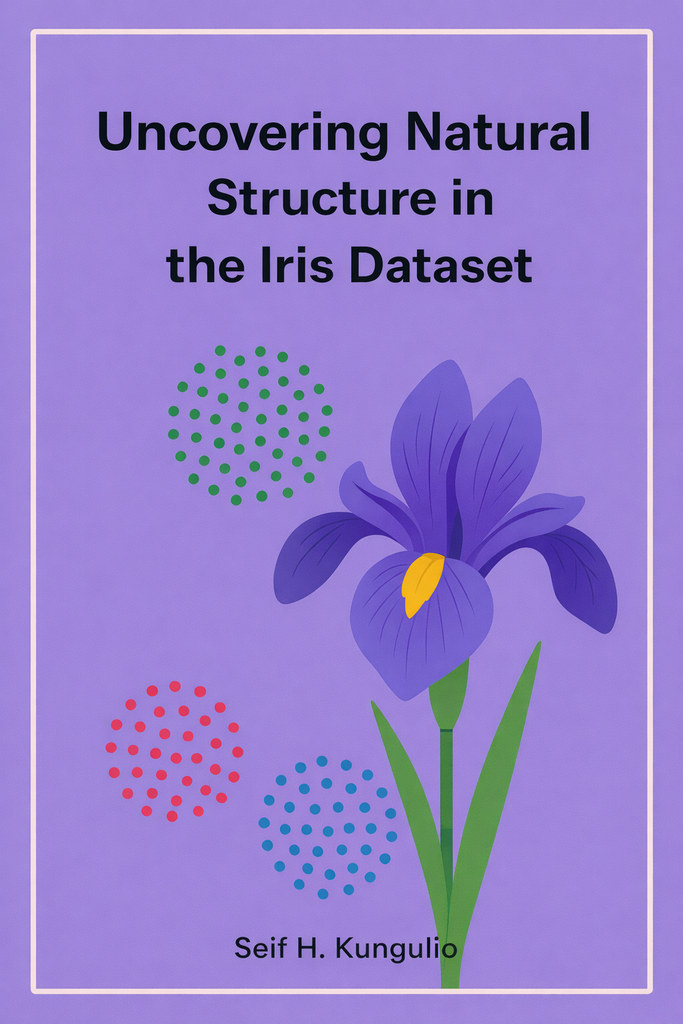

# Iris Cluster Analysis

## Business Overview

This project explores unsupervised learning techniques to uncover natural groupings within the classic Iris dataset using only numeric flower measurements. Although the dataset includes known species labels, they are intentionally excluded during modeling to simulate real-world scenarios where labels are unavailable or costly to obtain. The analysis demonstrates how clustering can support pattern discovery, exploratory insight generation, and preliminary classification tasks across domains such as biology, market segmentation, and anomaly detection.

## Problem Statement

The primary objective is to determine whether meaningful natural clusters exist within the Iris dataset based solely on numeric features (sepal length, sepal width, petal length, and petal width), and to evaluate how closely these clusters align with the known species categories. Specifically, the project seeks to: - Identify intrinsic groupings using unsupervised clustering techniques. - Determine the optimal number of clusters that best represent the underlying structure of the data. - Assess post-hoc alignment between discovered clusters and true species labels using quantitative evaluation metrics.

## Exploratory Data Analysis & Key Trends

Exploratory analysis revealed that petal measurements (length and width) exhibit significantly stronger variability and separation compared to sepal measurements. Pairwise plots and correlation analysis showed clear isolation of the setosa group, while versicolor and virginica displayed partial overlap. Univariate distributions further highlighted multimodal patterns in petal features, suggesting latent group structure. Principal Component Analysis (PCA) confirmed that the first two components capture approximately 96% of total variance, with petal variables driving most of the separation.

## Dashboard Preview

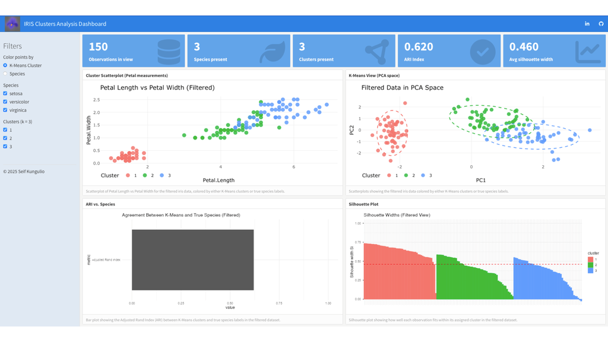

## Reflections & Lessons Learned

This project reinforces several key lessons in unsupervised learning: - Feature selection and scaling are critical, as clustering results are highly sensitive to variable magnitude and variance. - Multiple evaluation perspectives (geometric, statistical, and external validation) are essential for robust model selection. - Even well-known datasets benefit from an unsupervised lens, offering insights transferable to real-world problems where labels are absent.

Overall, the analysis highlights the effectiveness of K-Means for uncovering dominant structure in compact, well-behaved numeric datasets, while also demonstrating the value of comparing multiple clustering paradigms before deployment.